# گزارش فنی: تحلیل و شناخت داده‌های تشخیص اولیه دیابت

امیرعلی سطوتی

# 1 مقدمه و تعریف مسئله

**هدف پروژه:** هدف این پژوهش، توسعه یک سیستم هوشمند مبتنی بر داده‌کاوی برای پیش‌بینی احتمال ابتلا به دیابت است. این سیستم با تحلیل الگوهای موجود در علائم بالینی و ویژگی‌های فردی، ریسک ابتلا را ارزیابی می‌کند.

- **نوع مسئله:** یادگیری نظارت‌شده (Supervised Learning) - طبقه‌بندی دودویی (Binary Classification)
- **جامعه آماری:** شامل ۵۲۰ نمونه (Record) از افراد که برخی مبتلا و برخی سالم تشخیص داده شده‌اند.

# 2 ساختار مجموعه داده (Dataset Structure)

این مجموعه داده شامل ۵۲۰ سطر و ۱۷ ستون (بدون احتساب ستون ایندکس) است. داده‌ها ترکیبی از متغیرهای عددی و طبقه‌ای (Categorical) هستند که بسیاری از آن‌ها دارای مقادیر گم‌شده (Missing Values) می‌باشند که در فاز پیش‌پردازش نیازمند مدیریت هستند.

## 2.1 خلاصه آماری داده‌ها

- تعداد کل نمونه‌ها: ۵۲۰
- تعداد ویژگی‌ها (Features): ۱۶ ویژگی ورودی
- متغیر هدف (Target): ۱ متغیر (کلاس دیابت)

# 3 معرفی متغیرها و ویژگی‌ها (Feature Description)

متغیرهای موجود در این مجموعه داده به سه دسته کلی تقسیم می‌شوند: دموگرافیک، علائم بالینی و متغیر هدف.

## 3.1 ویژگی‌های دموگرافیک (Demographic Features)

این ویژگی‌ها اطلاعات عمومی فرد را توصیف می‌کنند:

- **Age (سن):** تنها متغیر عددی (Numerical) پیوسته در مجموعه داده که سن بیمار را نشان می‌دهد.
- **Gender (جنسیت):** متغیر اسمی (Nominal) شامل مقادیر Male (مرد) و Female (زن).

## 3.2 علائم بالینی و سوابق (Clinical Symptoms)

این متغیرها همگی از نوع طبقه‌ای (Categorical) و عمدتاً دودویی (Binary) هستند که وجود یا عدم وجود یک علامت را با مقادیر Yes (بله) یا No (خیر) نشان می‌دهند:

- **ExcessUrination (تکرر ادرار):** نیاز مکرر به دفع ادرار (پلی‌اوری).
- **Polydipsia (پرنوشی):** احساس تشنگی غیرطبیعی و مصرف زیاد آب.
- **WeightLossSudden (کاهش وزن ناگهانی):** از دست دادن وزن بدون رژیم غذایی خاص.
- **Fatigue (خستگی مفرط):** احساس ضعف و کمبود انرژی عمومی بدن.
- **Polyphagia (پرخوری):** اشتهای کاذب و بیش از حد.
- **GenitalThrush (برفک تناسلی):** عفونت قارچی که در بیماران دیابتی شایع است.
- **BlurredVision (تاری دید):** کاهش وضوح بینایی ناشی از نوسان قند خون.
- **Itching (خارش):** خارش پوست که می‌تواند ناشی از خشکی پوست یا عفونت باشد.
- **Irritability (تحریک‌پذیری):** تغییرات خلقی و زودرنجی.
- **DelayHealing (تاخیر در بهبودی زخم):** کند شدن روند ترمیم زخم‌ها.
- **PartialPsoriasis (پسوریازیس جزئی):** مشکلات پوستی مرتبط.
- **MuscleStiffness (سفتی عضلات):** گرفتگی یا سفتی در عضلات.
- **Alopecia (ریزش مو):** ریزش غیرطبیعی مو.
- **Obesity (چاقی):** شاخص توده بدنی بالا به عنوان یک ریسک فاکتور.

## 3.3 متغیر هدف (Target Variable)

**DiabeticClass:** این ستون برچسب نهایی هر نمونه است که وضعیت بیمار را مشخص می‌کند:

- **Positive:** فرد مبتلا به دیابت است.
- **Negative:** فرد سالم است.

# 4 ملاحظات مربوط به کیفیت داده (Data Quality Notes)

**چالش مقادیر گم‌شده (Missing Values):**

بررسی اولیه نشان می‌دهد که بخش قابل توجهی از داده‌ها دارای مقادیر `NaN` یا خالی هستند. به عنوان مثال، در ستون‌های Age، Gender و بسیاری از علائم بالینی، مقادیر ثبت‌نشده وجود دارد.

**راهکار پیشنهادی:** قبل از مدل‌سازی، نیاز است از تکنیک‌های پر کردن داده‌ها (Imputation) مانند جایگزینی با مد (برای متغیرهای طبقه‌ای) یا میانگین (برای سن) و یا حذف سطرها/ستون‌های بسیار ناقص استفاده شود.

# 5 اهمیت پزشکی (Medical Significance)

**تفسیر بالینی ویژگی‌ها:**

# 6 بارگذاری داده‌ها و کتابخانه‌های مورد نیاز

## 6.1 بارگذاری کتابخانه‌های مورد نیاز

اولین قدم، بارگذاری کتابخانه‌های لازم و بررسی اولیه داده‌ها برای درک ساختار، کیفیت و ویژگی‌های آماری آن است.

```r
library(tidyverse)      # دستکاری و مصورسازی داده‌ها
library(caret)          # یادگیری ماشین و آموزش مدل‌ها
library(rpart)          # درخت تصمیم (Decision Trees)
library(rpart.plot)     # مصورسازی درخت تصمیم
library(randomForest)   # جنگل تصادفی (Random Forest)
library(nnet)           # شبکه‌های عصبی (Neural Networks)
library(class)          # الگوریتم KNN
library(corrplot)       # ماتریس همبستگی
library(skimr)          # خلاصه‌سازی آماری
library(ggplot2)        # مصورسازی پیشرفته
```

کتابخانه tidyverse به عنوان مجموعه ابزار اصلی ما برای دستکاری داده‌ها (از طریق dplyr) و مصورسازی داده‌ها (با ggplot2) به کار می‌رود. برای فرآیندهای یادگیری ماشین، از کتابخانه caret جهت تقسیم داده‌ها به مجموعه‌های آموزشی و آزمایشی، پیش‌پردازش متغیرها و ارزیابی جامع عملکرد مدل‌ها استفاده می‌کنیم.

مدل اصلی ما با استفاده از کتابخانه rpart ساخته می‌شود که امکان ایجاد مدل‌های درخت تصمیم (CART) را فراهم می‌کند و کتابخانه rpart.plot برای ترسیم و مصورسازی زیبای این درختان تصمیم به کار گرفته می‌شود.

در مرحله اکتشاف داده‌ها (EDA)، از skimr برای ایجاد خلاصه‌های آماری غنی و سریع از دیتاست بهره می‌بریم. همچنین، کتابخانه‌های randomForest، nnet، class و corrplot برای مدل‌سازی و تحلیل پیشرفته‌تر استفاده می‌شوند.

## 6.2 بارگذاری مجموعه داده

```r
df <- read.csv("C:\\Users\\WIN10\\Desktop\\Diabetes.csv",
               na.strings = c("", "NA", "?", "NaN", " "))

dim(df)
```

```
## [1] 520  18
```

```r
str(df)
```

```
## 'data.frame':    520 obs. of  18 variables:
##  $ X               : int  1 2 3 4 5 6 7 8 9 10 ...
##  $ Age             : int  40 NA 41 NA 60 55 57 66 67 70 ...
##  $ Gender          : chr  "Male" NA "Male" NA ...
##  $ ExcessUrination : chr  NA "No" NA "No" ...
##  $ Polydipsia      : chr  NA NA "No" NA ...
##  $ WeightLossSudden: chr  NA "No" "No" "Yes" ...
##  $ Fatigue         : chr  NA "Yes" "Yes" NA ...
##  $ Polyphagia      : chr  NA "No" NA "Yes" ...
##  $ GenitalThrush   : chr  "No" "No" NA "Yes" ...
##  $ BlurredVision   : chr  NA "Yes" "No" NA ...
##  $ Itching         : chr  NA NA "Yes" "Yes" ...
##  $ Irritability    : chr  "No" "No" "No" "No" ...
##  $ DelayHealing    : chr  "Yes" NA NA "Yes" ...
##  $ PartialPsoriasis: chr  "No" "Yes" "No" "No" ...
##  $ MuscleStiffness : chr  "Yes" NA "Yes" NA ...
##  $ Alopecia        : chr  NA "Yes" "Yes" NA ...
##  $ Obesity         : chr  "Yes" "No" NA "No" ...
##  $ DiabeticClass   : chr  NA "Positive" "Positive" "Positive" ...
```

```r
skim(df)
```

Data summary

| Name | df |
| --- | --- |
| Number of rows | 520 |
| Number of columns | 18 |
| _______________________ |  |
| Column type frequency: |  |
| character | 16 |
| numeric | 2 |
| ________________________ |  |
| Group variables | None |

**Variable type: character**

| skim_variable | n_missing | complete_rate | min | max | empty | n_unique | whitespace |
| --- | --- | --- | --- | --- | --- | --- | --- |
| Gender | 218 | 0.58 | 4 | 6 | 0 | 2 | 0 |
| ExcessUrination | 182 | 0.65 | 2 | 3 | 0 | 2 | 0 |
| Polydipsia | 161 | 0.69 | 2 | 3 | 0 | 2 | 0 |
| WeightLossSudden | 150 | 0.71 | 2 | 3 | 0 | 2 | 0 |
| Fatigue | 202 | 0.61 | 2 | 3 | 0 | 2 | 0 |
| Polyphagia | 156 | 0.70 | 2 | 3 | 0 | 2 | 0 |
| GenitalThrush | 150 | 0.71 | 2 | 3 | 0 | 2 | 0 |
| BlurredVision | 150 | 0.71 | 2 | 3 | 0 | 2 | 0 |
| Itching | 166 | 0.68 | 2 | 3 | 0 | 2 | 0 |
| Irritability | 135 | 0.74 | 2 | 3 | 0 | 2 | 0 |
| DelayHealing | 156 | 0.70 | 2 | 3 | 0 | 2 | 0 |
| PartialPsoriasis | 176 | 0.66 | 2 | 3 | 0 | 2 | 0 |
| MuscleStiffness | 156 | 0.70 | 2 | 3 | 0 | 2 | 0 |
| Alopecia | 135 | 0.74 | 2 | 3 | 0 | 2 | 0 |
| Obesity | 130 | 0.75 | 2 | 3 | 0 | 2 | 0 |
| DiabeticClass | 176 | 0.66 | 8 | 8 | 0 | 2 | 0 |

**Variable type: numeric**

| skim_variable | n_missing | complete_rate | mean | sd | p0 | p25 | p50 | p75 | p100 | hist |
| --- | --- | --- | --- | --- | --- | --- | --- | --- | --- | --- |
| X | 0 | 1.00 | 260.50 | 150.26 | 1 | 130.75 | 260.5 | 390.25 | 520 | ▇▇▇▇▇ |
| Age | 140 | 0.73 | 47.85 | 12.33 | 16 | 38.00 | 47.0 | 57.00 | 90 | ▂▇▇▃▁ |

```r
head(df)
```

|  | X | Age | Gender | ExcessUrination | Polydipsia | WeightLossSudden | Fatigue | Polyphagia | GenitalThrush | BlurredVision | Itching | Irritability | DelayHealing | PartialPsoriasis | MuscleStiffness | Alopecia | Obesity | DiabeticClass |
| --- | --- | --- | --- | --- | --- | --- | --- | --- | --- | --- | --- | --- | --- | --- | --- | --- | --- | --- |
| 1 | 1 | 40 | Male | NA | NA | NA | NA | NA | No | NA | NA | No | Yes | No | Yes | NA | Yes | NA |
| 2 | 2 | NA | NA | No | NA | No | Yes | No | No | Yes | NA | No | NA | Yes | NA | Yes | No | Positive |
| 3 | 3 | 41 | Male | NA | No | No | Yes | NA | NA | No | Yes | No | NA | No | Yes | Yes | NA | Positive |
| 4 | 4 | NA | NA | No | NA | Yes | NA | Yes | Yes | NA | Yes | No | Yes | No | NA | NA | No | Positive |
| 5 | 5 | 60 | Male | Yes | Yes | NA | NA | Yes | No | Yes | NA | Yes | Yes | NA | NA | Yes | Yes | Positive |
| 6 | 6 | 55 | NA | NA | Yes | No | Yes | Yes | NA | Yes | Yes | NA | NA | No | Yes | NA | Yes | Positive |

استراتژی بارگذاری داده‌ها: در گام نخست، داده‌ها با استفاده از دستور read.csv فراخوانی شده‌اند. نکته کلیدی در این بخش، مدیریت هوشمندانه داده‌های نامعتبر در لحظه ورود است.

دستور اجرا شده: بسیاری از مجموعه‌های داده واقعی دارای فرمت‌های غیرواضح برای مقادیر گمشده هستند (مثل علامت سوال ?، فاصله خالی یا رشته NaN). با تنظیم پارامتر na.strings، تمامی این موارد به صورت یکسان به عنوان NA (Not Available) در نظر گرفته شده‌اند. این کار فرآیند پاکسازی بعدی را استاندارد می‌کند.

بررسی ابعاد و ساختار داده: خروجی dim(df) نشان می‌دهد که ماتریس داده‌ها دارای ۵۲۰ سطر (مشاهده) و ۱۸ ستون (ویژگی) است. خروجی str(df) نشان‌دهنده ناهمخوانی نوع داده‌ها با ماهیت آن‌هاست - اکثر متغیرهای طبقه‌ای به صورت chr (رشته متنی) شناخته شده‌اند که در مراحل بعد باید به Factor تبدیل شوند.

# 7 پیش‌پردازش داده‌ها (Data Pre-Processing)

## 7.1 آماده‌سازی اولیه داده‌ها

```r
df <- df[-1]
```

حذف ستون ایندکس: ستون اول (X) صرفاً یک شمارنده ردیف است و ارزش اطلاعاتی برای مدل‌سازی ندارد و باید حذف شود.

## 7.2 مدیریت داده‌های گمشده و پاکسازی

```r
df <- subset(df, !is.na(DiabeticClass))
df$DiabeticClass <- as.factor(df$DiabeticClass)
table(df$DiabeticClass)
```

```
##
## Negative Positive
##      120      224
```

```r
getmode <- function(v) {
  un <- unique(na.omit(v))
  un[which.max(tabulate(match(v, un)))]
}


df <- df %>%
  mutate(across(where(is.numeric),
                ~ifelse(is.na(.), median(., na.rm = TRUE), .))) %>%
  mutate(across(where(is.character),
                ~ifelse(is.na(.), getmode(.), .))) %>%
  mutate(across(where(is.factor),
                ~ifelse(is.na(.), getmode(.), .)))

sum(is.na(df))
```

```
## [1] 0
```

استراتژی پاکسازی: تعداد ۱۷۶ نمونه فاقد برچسب کلاس (NA) بودند. از آنجا که یادگیری مدل به روش نظارت‌شده (Supervised) است، امکان استفاده از داده‌های بدون برچسب وجود ندارد، لذا این سطرها حذف شدند.

استراتژی پر کردن داده‌های گمشده: برای حفظ حداکثری داده‌ها، به جای حذف ستون‌های دارای نقص، از روش‌های آماری برای تخمین مقادیر گمشده استفاده شد. برای متغیرهای عددی (سن) از میانه (Median) استفاده شد که مقاوم به داده‌های پرت است. برای متغیرهای طبقه‌ای (علائم و جنسیت) از مُد (Mode) یا پرتکرارترین مقدار استفاده شد.

وضعیت نهایی: پس از اجرای کدها، تعداد کل نمونه‌ها به ۳۴۴ رکورد کامل رسید و تعداد مقادیر گمشده به صفر رسید.

# 8 تحلیل اکتشافی داده‌ها (Exploratory Data Analysis)

## 8.1 تحلیل توزیع متغیر هدف

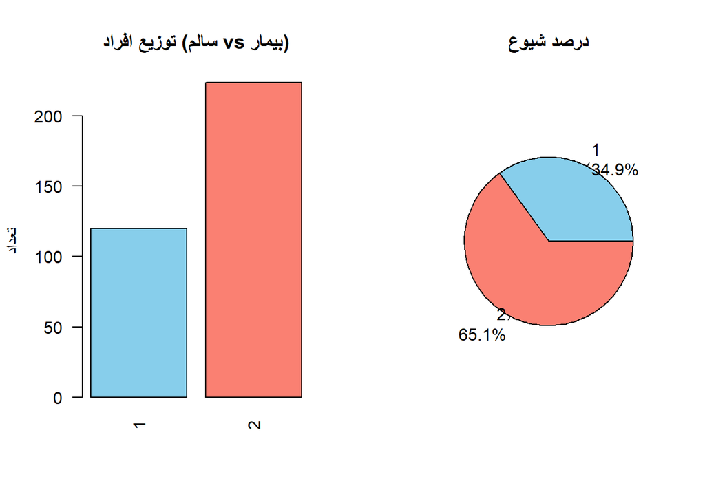

```r
par(mfrow = c(1, 2))

counts <- table(df$DiabeticClass)
colors <- c("skyblue", "salmon")


barplot(counts,
        main = "توزیع افراد (سالم vs بیمار)",
        col = colors,
        ylab = "تعداد",
        las = 2)

pct <- round(100 * counts / sum(counts), 1)
lbls <- paste(names(counts), "\n", pct, "%", sep="")
pie(counts, labels = lbls, col = colors, main = "درصد شیوع")
```

```r
par(mfrow = c(1, 1))
```

تحلیل توزیع متغیر هدف: نمودارهای میله‌ای و دایره‌ای نشان‌دهنده توزیع بیماران در دو کلاس Positive و Negative هستند. عدم تعادل در کلاس‌ها (Imbalance) مشاهده می‌شود. در مرحله آموزش مدل، باید از معیارهایی مانند F1-Score یا AUC استفاده کنیم، زیرا معیار دقت (Accuracy) به تنهایی می‌تواند گمراه‌کننده باشد.

## 8.2 تحلیل دموگرافیک: سن

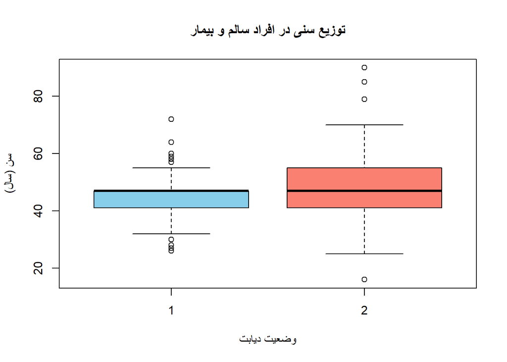

```r
boxplot(Age ~ DiabeticClass, data = df,
        main = "توزیع سنی در افراد سالم و بیمار",
        xlab = "وضعیت دیابت",
        ylab = "سن (سال)",
        col = c("skyblue", "salmon"),
        border = "black")
```

```r
max(df$Age)
```

```
## [1] 90
```

```r
min(df$Age)
```

```
## [1] 16
```

## 8.3 تحلیل علائم بالینی کلیدی

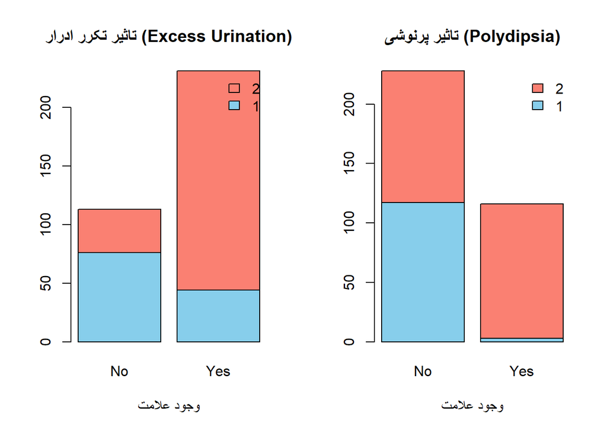

```r
par(mfrow = c(1, 2))

tab_urination <- table(df$DiabeticClass, df$ExcessUrination)
barplot(tab_urination,
        main = "تاثیر تکرر ادرار (Excess Urination)",
        xlab = "وجود علامت",
        col = c("skyblue", "salmon"),
        legend = rownames(tab_urination),
        args.legend = list(x = "topright", bty = "n"))


tab_polydipsia <- table(df$DiabeticClass, df$Polydipsia)
barplot(tab_polydipsia,
        main = "تاثیر پرنوشی (Polydipsia)",
        xlab = "وجود علامت",
        col = c("skyblue", "salmon"),
        legend = rownames(tab_polydipsia),
        args.legend = list(x = "topright", bty = "n"))
```

```r
par(mfrow = c(1, 1))
```

تحلیل علائم کلیدی: تمرکز اصلی بر روی دو علامت کلاسیک دیابت است: تکرر ادرار (Excess Urination) و پرنوشی (Polydipsia). نمودارهای میله‌ای تفکیکی نشان می‌دهند که در گروه بیماران دیابتی، ستون Yes برای این دو علامت به طرز چشمگیری بلندتر از گروه سالم است. این یافته‌ها تایید می‌کند که این دو علامت، قوی‌ترین سیگنال‌های هشداردهنده برای تشخیص دیابت هستند.

## 8.4 تحلیل جامع و مهندسی ویژگی

```r
library(gridExtra)
if (is.integer(df[,1]) && df[1,1] == 1) {
  df <- df[-1]
}

df <- df %>% filter(!is.na(DiabeticClass))

getmode <- function(v) {
  un <- unique(na.omit(v))
  un[which.max(tabulate(match(v, un)))]
}

df <- df %>%
  mutate(across(where(is.numeric), ~ifelse(is.na(.), median(., na.rm = TRUE), .))) %>%
  mutate(across(where(is.character) | where(is.factor), ~ifelse(is.na(.), getmode(.), .)))

df$DiabeticClass <- as.factor(df$DiabeticClass)

# Feature Engineering
df_numeric <- df %>%
  mutate(across(everything(), ~case_when(
    as.character(.) %in% c("Yes", "Positive", "Male") ~ 1,
    as.character(.) %in% c("No", "Negative", "Female") ~ 0,
    TRUE ~ suppressWarnings(as.numeric(as.character(.)))
  )))

symptom_vars <- setdiff(names(df_numeric), c("Age", "Gender", "DiabeticClass"))
df$Symptom_Score <- rowSums(df_numeric[, symptom_vars], na.rm = TRUE)

df$Age_Group <- cut(df$Age,
                    breaks = c(0, 30, 50, 100),
                    labels = c("Young", "Middle-Aged", "Senior"))

# Statistical Tests
cat("\n--- Chi-Square Test Results ---\n")
```

```
##
## --- Chi-Square Test Results ---
```

```r
vars_to_test <- setdiff(names(df), c("Age", "DiabeticClass", "Symptom_Score", "Age_Group"))

for (var in vars_to_test) {
  if(var %in% names(df)){
    tbl <- table(df[[var]], df$DiabeticClass)
    if(nrow(tbl) > 1 && ncol(tbl) > 1) {
      test <- chisq.test(tbl)
      if(test$p.value < 0.05) {
        cat(sprintf("✅ %-20s (P-value = %.4f) -> Significant\n", var, test$p.value))
      }
    }
  }
}
```

```
## ✅ Gender               (P-value = 0.0000) -> Significant
## ✅ ExcessUrination      (P-value = 0.0000) -> Significant
## ✅ Polydipsia           (P-value = 0.0000) -> Significant
## ✅ WeightLossSudden     (P-value = 0.0000) -> Significant
## ✅ Polyphagia           (P-value = 0.0000) -> Significant
## ✅ BlurredVision        (P-value = 0.0004) -> Significant
## ✅ Irritability         (P-value = 0.0000) -> Significant
## ✅ PartialPsoriasis     (P-value = 0.0000) -> Significant
## ✅ MuscleStiffness      (P-value = 0.0240) -> Significant
## ✅ Alopecia             (P-value = 0.0032) -> Significant
```

```r
# Modeling (Random Forest)
set.seed(123)
rf_model <- randomForest(DiabeticClass ~ .,
                         data = df %>% select(-Age_Group, -Symptom_Score),
                         importance = TRUE,
                         ntree = 100)

importance_df <- as.data.frame(importance(rf_model))
importance_df$Feature <- rownames(importance_df)
importance_df <- importance_df %>% arrange(desc(MeanDecreaseGini))

print("\n--- Top 5 Predictors ---")
```

```
## [1] "\n--- Top 5 Predictors ---"
```

```r
print(head(importance_df[, c("Feature", "MeanDecreaseGini")], 5))
```

```
##                           Feature MeanDecreaseGini
## Polydipsia             Polydipsia        25.065213
## Age                           Age        21.873630
## ExcessUrination   ExcessUrination        17.073643
## WeightLossSudden WeightLossSudden         9.614289
## PartialPsoriasis PartialPsoriasis         7.160743
```

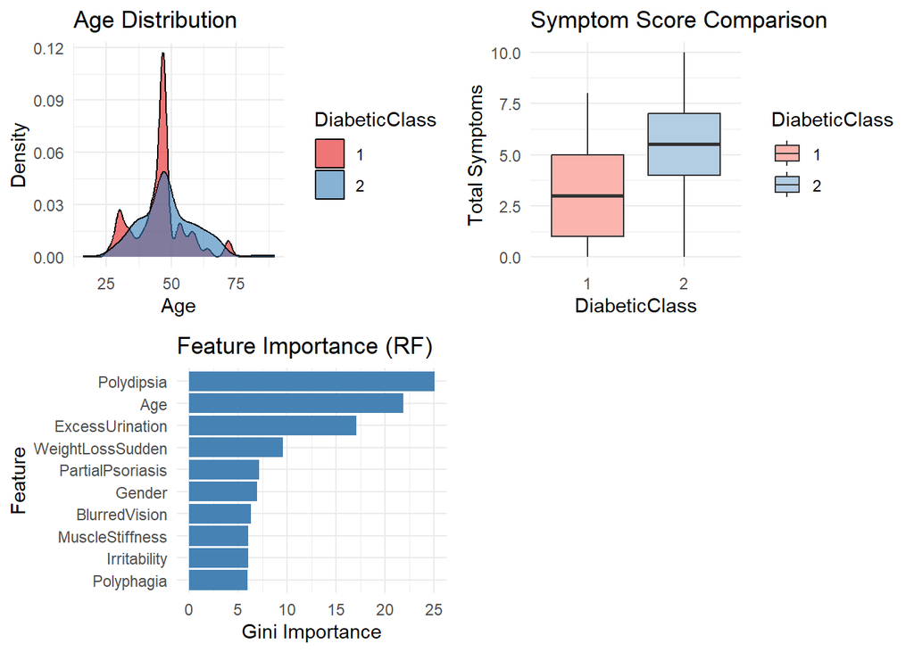

```r
# Visualization
p1 <- ggplot(df, aes(x = Age, fill = DiabeticClass)) +
  geom_density(alpha = 0.6) +
  labs(title = "Age Distribution", x = "Age", y = "Density") +
  theme_minimal() + scale_fill_brewer(palette = "Set1")

p2 <- ggplot(df, aes(x = DiabeticClass, y = Symptom_Score, fill = DiabeticClass)) +
  geom_boxplot() +
  labs(title = "Symptom Score Comparison", y = "Total Symptoms") +
  theme_minimal() + scale_fill_brewer(palette = "Pastel1")

p3 <- ggplot(head(importance_df, 10), aes(x = reorder(Feature, MeanDecreaseGini), y = MeanDecreaseGini)) +
  geom_bar(stat = "identity", fill = "steelblue") +
  coord_flip() +
  labs(title = "Feature Importance (RF)", x = "Feature", y = "Gini Importance") +
  theme_minimal()

grid.arrange(p1, p2, p3, ncol = 2)
```

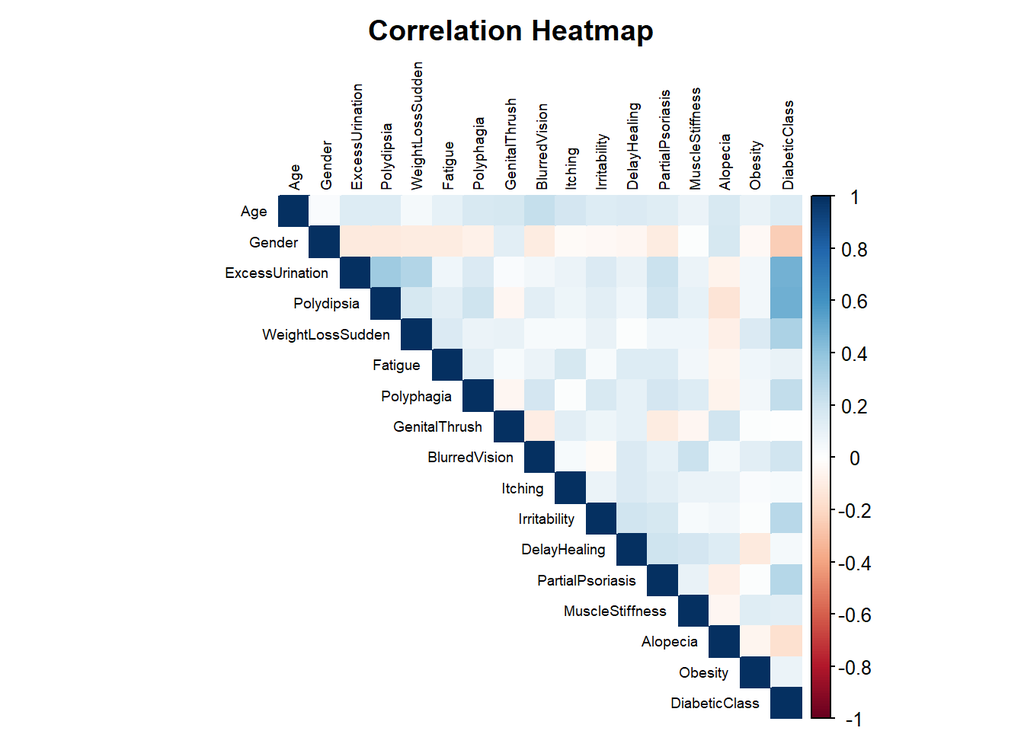

```r
df_numeric_clean <- df_numeric %>% select_if(~ !any(is.na(.)))
cor_matrix <- cor(df_numeric_clean, use = "complete.obs")

corrplot(cor_matrix, method = "color", type = "upper",
         tl.col = "black", tl.cex = 0.6,
         title = "Correlation Heatmap", mar=c(0,0,2,0))
```

# 9 مدل‌سازی و ارزیابی عملکرد

## 9.1 تقسیم داده‌ها به آموزش و آزمون

```r
set.seed(123)
train_idx <- createDataPartition(df$DiabeticClass, p = 0.7, list = FALSE)
train <- df[train_idx, ]
test  <- df[-train_idx, ]
```

داده‌های پیش‌پردازش شده به دو بخش آموزش (۷۰٪) و آزمون (۳۰٪) تقسیم شدند. این تقسیم به صورت طبقه‌بندی شده (stratified) انجام شد تا نسبت کلاس‌ها در هر دو مجموعه حفظ شود.

## 9.2 آموزش مدل‌های مختلف

### 9.2.1 مدل KNN

```r
model_knn <- train(
  DiabeticClass ~ .,
  data = train,
  method = "knn",
  preProcess = c("center", "scale")
)
```

مدل KNN: این مدل مبتنی بر فاصله است و نیاز به استانداردسازی داده‌ها دارد که با preProcess انجام می‌شود.

### 9.2.2 مدل درخت تصمیم

```r
model_tree <- train(
  DiabeticClass ~ .,
  data = train,
  method = "rpart"
)
```

مدل درخت تصمیم: این مدل مبتنی بر قوانین است و نیاز به پیش‌پردازش خاصی ندارد.

### 9.2.3 مدل جنگل تصادفی

```r
model_rf <- train(
  DiabeticClass ~ .,
  data = train,
  method = "rf"
)
```

مدل جنگل تصادفی: این مدل مبتنی بر آنسامبل است و معمولاً عملکرد بهتری نسبت به درخت تصمیم دارد.

### 9.2.4 مدل شبکه عصبی

```r
model_nnet <- train(
  DiabeticClass ~ .,
  data = train,
  method = "nnet",
  preProcess = c("center", "scale"),
  trace = FALSE
)
```

مدل شبکه عصبی: این مدل نیاز به استانداردسازی داده‌ها دارد و به دلیل حساسیت به مقیاس، preProcess حیاتی است.

### 9.2.5 مدل SVM

```r
model_svm <- train(
  DiabeticClass ~ .,
  data = train,
  method = "svmRadial",
  preProcess = c("center", "scale")
)
```

مدل SVM: این مدل مبتنی بر حاشیه و بردار پشتیبان است و نیاز به استانداردسازی دارد.

### 9.2.6 مدل LDA

```r
model_lda <- train(
  DiabeticClass ~ .,
  data = train,
  method = "lda",
  preProcess = c("center", "scale")
)
```

مدل LDA: این مدل مبتنی بر آمار خطی است. ممکن است هشدارهای collinearity دریافت شود زیرا LDA به هم‌خطی بسیار حساس است.

## 9.3 مصورسازی مدل‌ها

### 9.3.1 نمودار درخت تصمیم

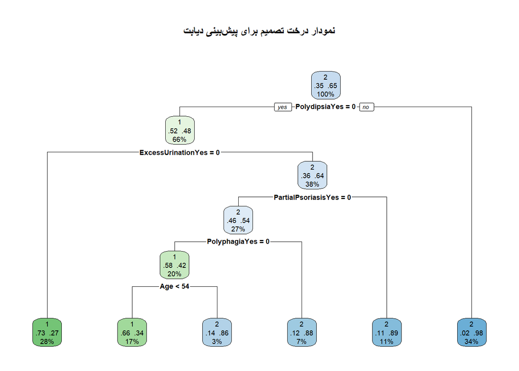

```r
library(rpart.plot)
rpart.plot(model_tree$finalModel,
           type = 2,
           extra = 104,
           box.palette = "GnBu",
           main = "نمودار درخت تصمیم برای پیش‌بینی دیابت")
```

نمودار درخت تصمیم: این نمودار مسیر تصمیم‌گیری مدل را نشان می‌دهد و به راحتی قابل تفسیر است.

### 9.3.2 تنظیم پارامتر KNN

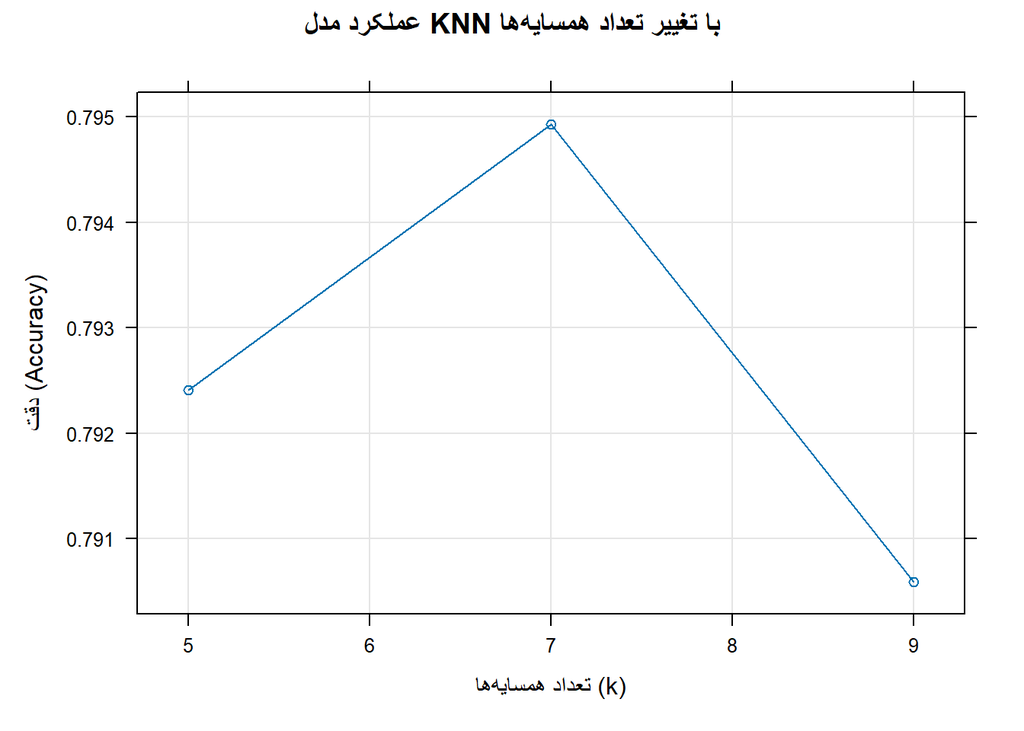

```r
plot(model_knn,
     main = "عملکرد مدل KNN با تغییر تعداد همسایه‌ها",
     xlab = "تعداد همسایه‌ها (k)",
     ylab = "دقت (Accuracy)")
```

```r
model_knn$bestTune
```

|  | k |
| --- | --- |
| 2 | 7 |

تنظیم پارامتر KNN: این نمودار نشان می‌دهد که با تغییر تعداد همسایه‌ها، دقت مدل چگونه تغییر می‌کند.

### 9.3.3 اهمیت ویژگی‌ها در جنگل تصادفی

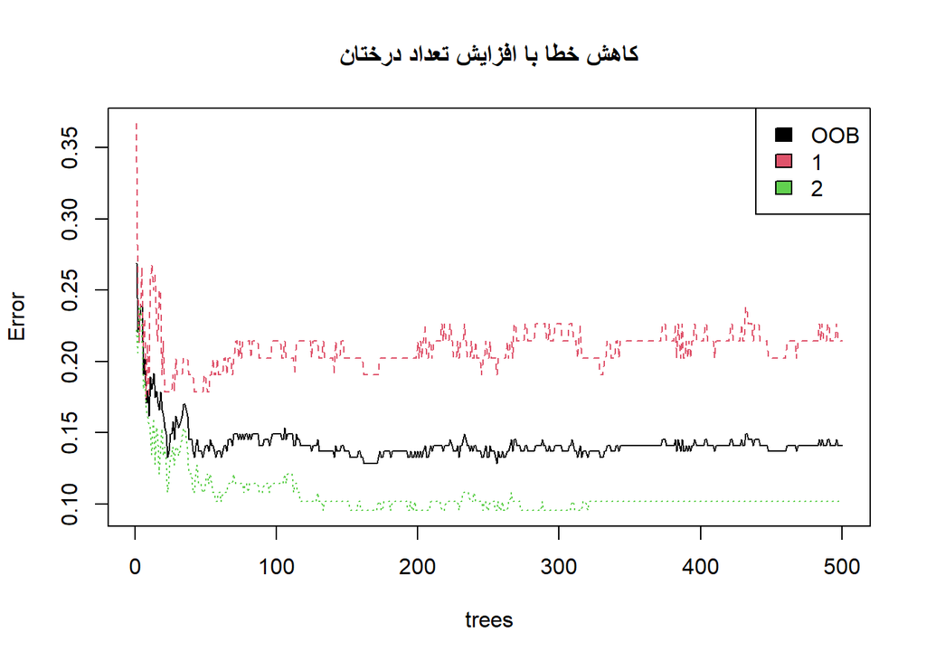

```r
if(model_rf$method == "rf") {
  plot(model_rf$finalModel, main = "کاهش خطا با افزایش تعداد درختان")
  legend("topright", colnames(model_rf$finalModel$err.rate), col=1:3, fill=1:3)
}
```

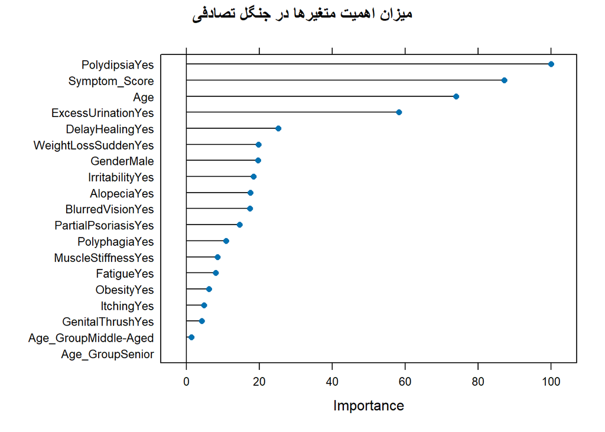

```r
plot(varImp(model_rf), main = "میزان اهمیت متغیرها در جنگل تصادفی")
```

اهمیت ویژگی‌ها: نمودار اول نشان می‌دهد که خطا با افزایش تعداد درختان کاهش می‌یابد. نمودار دوم نشان می‌دهد کدام متغیرها بیشترین تاثیر را در پیش‌بینی داشته‌اند.

## 9.4 ارزیابی و مقایسه مدل‌ها

```r
all_models <- list(
  KNN = model_knn,
  DecisionTree = model_tree,
  RandomForest = model_rf,
  NeuralNet = model_nnet,
  SVM = model_svm,
  LDA = model_lda
)


pos_class <- levels(test$DiabeticClass)[2]
cat("کلاس مثبت تشخیص داده شده:", pos_class, "\n")
```

```
## کلاس مثبت تشخیص داده شده: 2
```

```r
results_table <- t(sapply(all_models, function(mod) {


  pred <- predict(mod, newdata = test)

  pred <- factor(pred, levels = levels(test$DiabeticClass))


  cm <- confusionMatrix(pred, test$DiabeticClass, positive = pos_class)

  c(Accuracy = round(cm$overall["Accuracy"], 3),
    F1_Score = round(cm$byClass["F1"], 3),
    Sensitivity = round(cm$byClass["Sensitivity"], 3),
    Specificity = round(cm$byClass["Specificity"], 3)
  )
}))


results_df <- as.data.frame(results_table)
results_df <- results_df[order(-results_df$F1_Score), ]
print(results_df)
```

```
##              Accuracy.Accuracy F1_Score.F1 Sensitivity.Sensitivity
## NeuralNet                0.854       0.884                   0.851
## RandomForest             0.835       0.868                   0.836
## SVM                      0.825       0.866                   0.866
## KNN                      0.825       0.862                   0.836
## LDA                      0.816       0.853                   0.821
## DecisionTree             0.767       0.800                   0.716
##              Specificity.Specificity
## NeuralNet                      0.861
## RandomForest                   0.833
## SVM                            0.750
## KNN                            0.806
## LDA                            0.806
## DecisionTree                   0.861
```

جدول مقایسه: این جدول چهار معیار کلیدی (Accuracy, F1_Score, Sensitivity, Specificity) را برای تمام مدل‌ها نشان می‌دهد. مدل‌ها بر اساس F1-Score مرتب شده‌اند که معیار مهمی برای ارزیابی عملکرد در داده‌های نامتعادل است.

## 9.5 مصورسازی مقایسه مدل‌ها

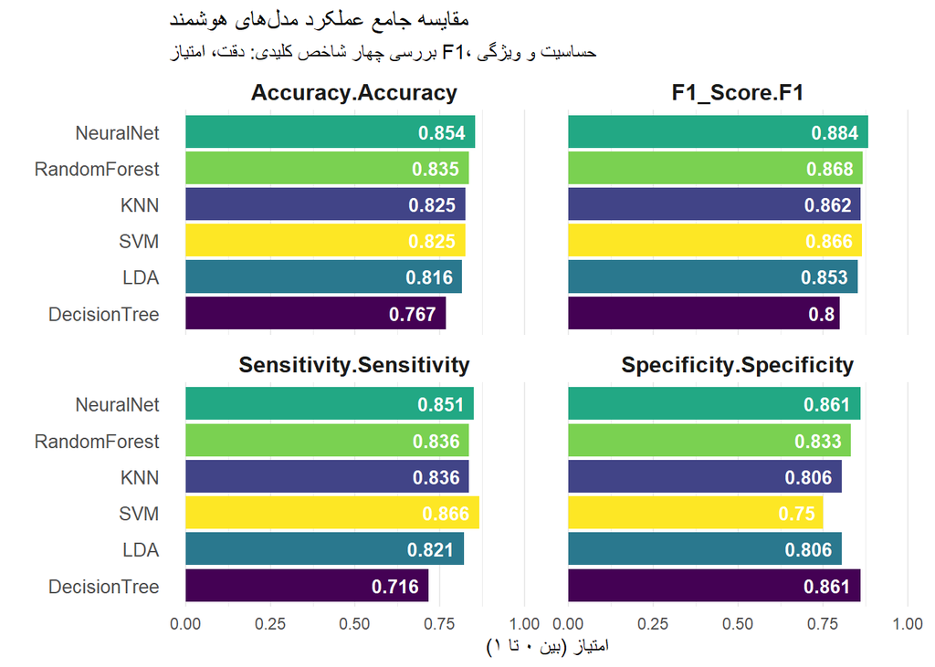

```r
library(tidyverse)

plot_data <- results_df %>%
  rownames_to_column(var = "Model") %>%
  pivot_longer(
    cols = -Model,
    names_to = "Metric",
    values_to = "Score"
  )

ggplot(plot_data, aes(x = reorder(Model, Score), y = Score, fill = Model)) +
  geom_bar(stat = "identity", show.legend = FALSE) +
  facet_wrap(~ Metric, scales = "fixed") +
  coord_flip() +
  geom_text(aes(label = Score), hjust = 1.2, color = "white", size = 3.5, fontface = "bold") +
  scale_fill_viridis_d(option = "D") +
  scale_y_continuous(limits = c(0, 1)) +
  theme_minimal() +
  theme(
    strip.text = element_text(size = 12, face = "bold"),
    axis.text.y = element_text(size = 10),
    panel.grid.major.y = element_blank()
  ) +
  labs(title = "مقایسه جامع عملکرد مدل‌های هوشمند",
       subtitle = "بررسی چهار شاخص کلیدی: دقت، امتیاز F1، حساسیت و ویژگی",
       x = "",
       y = "امتیاز (بین ۰ تا ۱)")
```

# 10 نتیجه‌گیری نهایی